# PCA analysis of human data

Jussi Jaatinen

# PCA analysis of human data

### Overview of data

Data for this analysis is from the United Nations Development Programme. Two datasets have been combined, Human Development Index (HDI) and Gender Inequality Index (GII). As a result, the new dataset includes following variables:

- Life_Exp = Expected lifetime in years
- Edu_Exp = Expected education time in years
- GNI = Gross National Income
- Mat_Mortal = Maternal mortality per 1000
- Teen_Preg = Teen pregnancy per 1000
- F_Rep_Parl = Female members in parliament (%)
- Edu_Rto_FM = Ratio between females and males in education
- Work_Rto_FM = Ratio between females and males in labour

Most of variables are to some extend skewed. In correlation matrix high positive and negative correlations can be throughout seen. Actually, most of the variables of this dataset correlated strongly. Only F_Rep_Parl and Work_Rto_FM had weak correlations to all other variables (except each other).

```
    Life_Exp        Edu_Exp           GNI           Mat_Mortal
 Min.   :49.00   Min.   : 5.40   Min.   :   581   Min.   :   1.0
 1st Qu.:66.30   1st Qu.:11.25   1st Qu.:  4198   1st Qu.:  11.5
 Median :74.20   Median :13.50   Median : 12040   Median :  49.0
 Mean   :71.65   Mean   :13.18   Mean   : 17628   Mean   : 149.1
 3rd Qu.:77.25   3rd Qu.:15.20   3rd Qu.: 24512   3rd Qu.: 190.0
 Max.   :83.50   Max.   :20.20   Max.   :123124   Max.   :1100.0
   Teen_Preg        F_Rep_Parl      Edu_Rto_FM      Work_Rto_FM
 Min.   :  0.60   Min.   : 0.00   Min.   :0.1717   Min.   :0.1857
 1st Qu.: 12.65   1st Qu.:12.40   1st Qu.:0.7264   1st Qu.:0.5984
 Median : 33.60   Median :19.30   Median :0.9375   Median :0.7535
 Mean   : 47.16   Mean   :20.91   Mean   :0.8529   Mean   :0.7074
 3rd Qu.: 71.95   3rd Qu.:27.95   3rd Qu.:0.9968   3rd Qu.:0.8535
 Max.   :204.80   Max.   :57.50   Max.   :1.4967   Max.   :1.0380
```

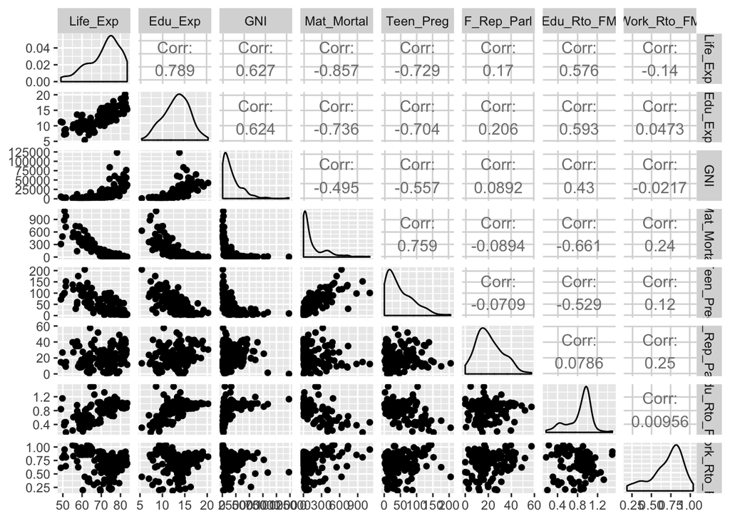

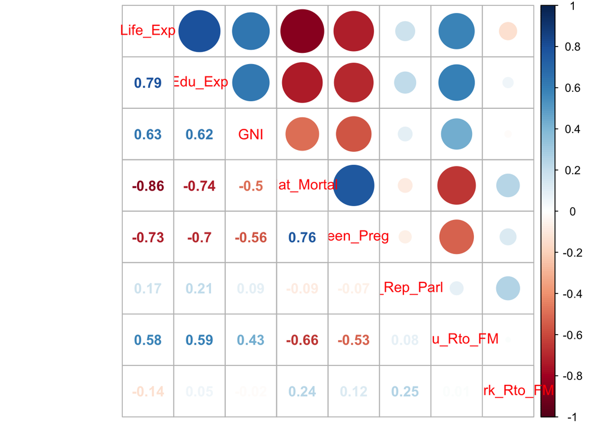

### Principal component analysis (PCA)

In principal component analysis the original multidimensional data is transformed to new space. Most of the cases the number of dimensions has been diminished. The new dimensions are called principal components, which are uncorrelated to each other. The first principal component explains maximum amount of variance in original data. The second component is orthogonal to the first and explains maximum variance left. This principle continues similarly with next components and each of them are less important compared to the previous one. If eigenvalue of the component is smaller than one, it usually can be left out. In biplots, PC1 is usually visualized on x-axis and PC2 in y-axis. Arrows and labels show connections between the original features and the principal components (usually PC1 and PC2).

In biplots angles between arrows correspond correlations of the original features. The smaller the angle, the higher is positive correlation. If two arrows are parallel but point to opposite directions, it indicates high negative correlation. 90 degree’s angle means zero correlation (orthogonal = compare to x-axis (PC1) and y-axis (PC2)). The length of the arrows shows the standard deviations of the original features.

```
    Life_Exp        Edu_Exp           GNI           Mat_Mortal
 Min.   :49.00   Min.   : 5.40   Min.   :   581   Min.   :   1.0
 1st Qu.:66.30   1st Qu.:11.25   1st Qu.:  4198   1st Qu.:  11.5
 Median :74.20   Median :13.50   Median : 12040   Median :  49.0
 Mean   :71.65   Mean   :13.18   Mean   : 17628   Mean   : 149.1
 3rd Qu.:77.25   3rd Qu.:15.20   3rd Qu.: 24512   3rd Qu.: 190.0
 Max.   :83.50   Max.   :20.20   Max.   :123124   Max.   :1100.0
   Teen_Preg        F_Rep_Parl      Edu_Rto_FM      Work_Rto_FM
 Min.   :  0.60   Min.   : 0.00   Min.   :0.1717   Min.   :0.1857
 1st Qu.: 12.65   1st Qu.:12.40   1st Qu.:0.7264   1st Qu.:0.5984
 Median : 33.60   Median :19.30   Median :0.9375   Median :0.7535
 Mean   : 47.16   Mean   :20.91   Mean   :0.8529   Mean   :0.7074
 3rd Qu.: 71.95   3rd Qu.:27.95   3rd Qu.:0.9968   3rd Qu.:0.8535
 Max.   :204.80   Max.   :57.50   Max.   :1.4967   Max.   :1.0380
```

```
Importance of components:
                             PC1      PC2   PC3   PC4   PC5   PC6    PC7
Standard deviation     1.854e+04 185.5219 25.19 11.45 3.766 1.566 0.1912
Proportion of Variance 9.999e-01   0.0001  0.00  0.00 0.000 0.000 0.0000
Cumulative Proportion  9.999e-01   1.0000  1.00  1.00 1.000 1.000 1.0000
                          PC8
Standard deviation     0.1591
Proportion of Variance 0.0000
Cumulative Proportion  1.0000
```

```
PC1 PC2 PC3 PC4 PC5 PC6 PC7 PC8
100   0   0   0   0   0   0   0
```

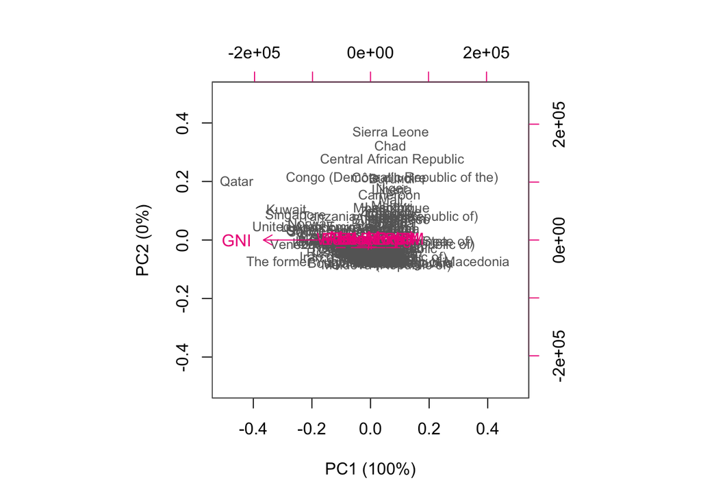

### Standardization of data and PCA

Due to PCA is sensitive to the scaling, large variance of the original feature get greater importance compared to a feature with smaller variance. Standardization of the original data equalizes importance between original fatures.

In following table and biplot below, PCA analysis itself is the same as above, but original data has been standardized before calculating PCA.

Variable GNI has extreme values compared to the all other variables. If data is not standardized, it change results significantly. As seen in table, in original data, importance of PC1 is 100%, due to GNI. When data is standardized, the values of GNI are closer to other variables and there are more explanatory variables, which have significance. Now, PC1 explains 53% of variance and PC2 16%.

It must be mentioned, if you do PCA analysis with PCA function (FactoMineR) instead of prcomp (used in this analysis), it gives similar importance for PCs whether data is standardized or not.

```
    Life_Exp          Edu_Exp             GNI            Mat_Mortal
 Min.   :-2.7188   Min.   :-2.7378   Min.   :-0.9193   Min.   :-0.6992
 1st Qu.:-0.6425   1st Qu.:-0.6782   1st Qu.:-0.7243   1st Qu.:-0.6496
 Median : 0.3056   Median : 0.1140   Median :-0.3013   Median :-0.4726
 Mean   : 0.0000   Mean   : 0.0000   Mean   : 0.0000   Mean   : 0.0000
 3rd Qu.: 0.6717   3rd Qu.: 0.7126   3rd Qu.: 0.3712   3rd Qu.: 0.1932
 Max.   : 1.4218   Max.   : 2.4730   Max.   : 5.6890   Max.   : 4.4899
   Teen_Preg         F_Rep_Parl        Edu_Rto_FM       Work_Rto_FM
 Min.   :-1.1325   Min.   :-1.8203   Min.   :-2.8189   Min.   :-2.6247
 1st Qu.:-0.8394   1st Qu.:-0.7409   1st Qu.:-0.5233   1st Qu.:-0.5484
 Median :-0.3298   Median :-0.1403   Median : 0.3503   Median : 0.2316
 Mean   : 0.0000   Mean   : 0.0000   Mean   : 0.0000   Mean   : 0.0000
 3rd Qu.: 0.6030   3rd Qu.: 0.6127   3rd Qu.: 0.5958   3rd Qu.: 0.7350
 Max.   : 3.8344   Max.   : 3.1850   Max.   : 2.6646   Max.   : 1.6632
```

```
Importance of components:
                          PC1    PC2     PC3     PC4     PC5     PC6
Standard deviation     2.0708 1.1397 0.87505 0.77886 0.66196 0.53631
Proportion of Variance 0.5361 0.1624 0.09571 0.07583 0.05477 0.03595
Cumulative Proportion  0.5361 0.6984 0.79413 0.86996 0.92473 0.96069
                           PC7     PC8
Standard deviation     0.45900 0.32224
Proportion of Variance 0.02634 0.01298
Cumulative Proportion  0.98702 1.00000
```

```
 PC1  PC2  PC3  PC4  PC5  PC6  PC7  PC8
53.6 16.2  9.6  7.6  5.5  3.6  2.6  1.3
```

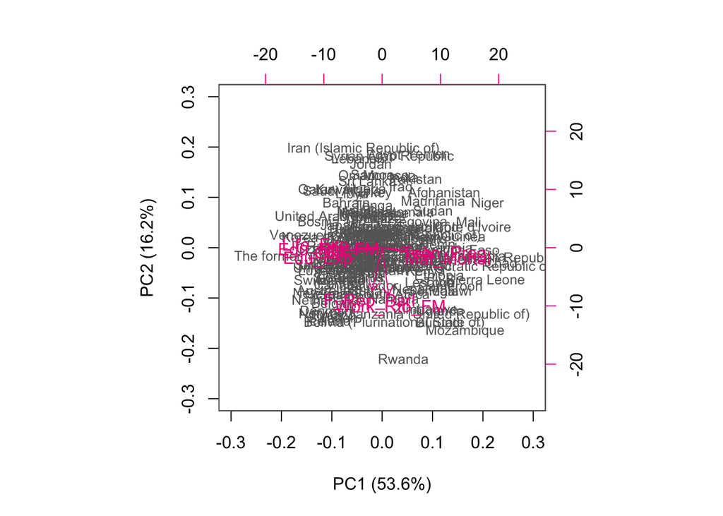

### Interpretations of PC1 and PC2

PC1 includes most of the highly correlated variables together and could be interepretated as “goodness” of life. Bigger Gross Nation Income, longer life expectancy, longer education and Ratio between females and males in education (closer to 1) all can be expected to make life and society better. In the same component Maternal mortality and Teen pregnancy correlate negatively and make life worse. Component PC2 could explain equality between genders in a society. If Female members in parliament (%) is bigger, it usually mean that Ratio between females and males in labour is also closer to 1 and women are more equal members of the society.

### Tea

Tea data is included to R package and is a questionnaire on tea. 300 participant were asked how they drink tea, what are their product’s perception and some personal details. There are totally 36 variables, of which 6 are included into this dataset.

Categorical variables (factor) are:

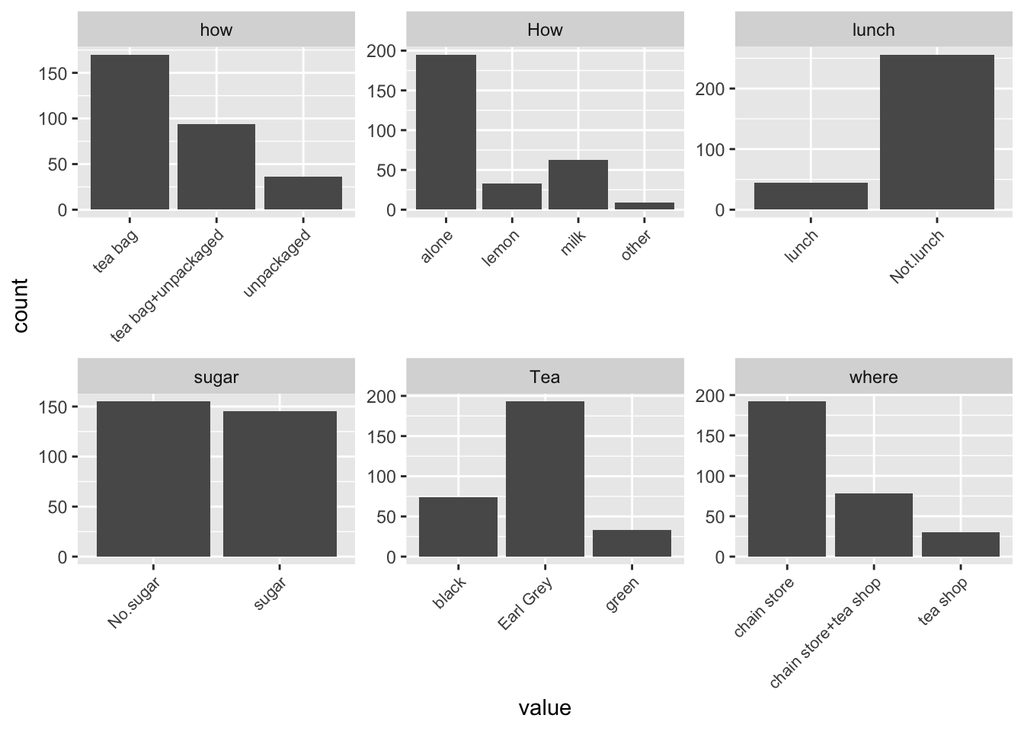

### Multiple Correspondence Analysis on the tea data

In MCA plots categorical variables are grouped by correlations to each other or components. For example in biplot below can be seen that unpackaged tea is usually drunk in tea shops, whereas tea bag is mostly used in chain stores. Actually in both dimensions variables “how” (Tea bag, Tea bag + unpackaged, Unpackaged) and “where” (Chain store, Chain store + tea shop, Tea shop) were the most significant variables.

```
Call:
MCA(X = tea_time, graph = FALSE)


Eigenvalues
                       Dim.1   Dim.2   Dim.3   Dim.4   Dim.5   Dim.6
Variance               0.279   0.261   0.219   0.189   0.177   0.156
% of var.             15.238  14.232  11.964  10.333   9.667   8.519
Cumulative % of var.  15.238  29.471  41.435  51.768  61.434  69.953
                       Dim.7   Dim.8   Dim.9  Dim.10  Dim.11
Variance               0.144   0.141   0.117   0.087   0.062
% of var.              7.841   7.705   6.392   4.724   3.385
Cumulative % of var.  77.794  85.500  91.891  96.615 100.000

Individuals (the 10 first)
                      Dim.1    ctr   cos2    Dim.2    ctr   cos2    Dim.3
1                  | -0.298  0.106  0.086 | -0.328  0.137  0.105 | -0.327
2                  | -0.237  0.067  0.036 | -0.136  0.024  0.012 | -0.695
3                  | -0.369  0.162  0.231 | -0.300  0.115  0.153 | -0.202
4                  | -0.530  0.335  0.460 | -0.318  0.129  0.166 |  0.211
5                  | -0.369  0.162  0.231 | -0.300  0.115  0.153 | -0.202
6                  | -0.369  0.162  0.231 | -0.300  0.115  0.153 | -0.202
7                  | -0.369  0.162  0.231 | -0.300  0.115  0.153 | -0.202
8                  | -0.237  0.067  0.036 | -0.136  0.024  0.012 | -0.695
9                  |  0.143  0.024  0.012 |  0.871  0.969  0.435 | -0.067
10                 |  0.476  0.271  0.140 |  0.687  0.604  0.291 | -0.650
                      ctr   cos2
1                   0.163  0.104 |
2                   0.735  0.314 |
3                   0.062  0.069 |
4                   0.068  0.073 |
5                   0.062  0.069 |
6                   0.062  0.069 |
7                   0.062  0.069 |
8                   0.735  0.314 |
9                   0.007  0.003 |
10                  0.643  0.261 |

Categories (the 10 first)
                       Dim.1     ctr    cos2  v.test     Dim.2     ctr
```

[output cut: 15 more lines]

```
lemon                0.035   3.226 |   1.329  14.771   0.218   8.081 |
milk                 0.020   2.422 |   0.013   0.003   0.000   0.116 |
other                0.102   5.534 |  -2.524  14.526   0.197  -7.676 |
tea bag              0.161  -6.941 |  -0.065   0.183   0.006  -1.287 |
tea bag+unpackaged   0.478  11.956 |   0.019   0.009   0.000   0.226 |
unpackaged           0.141  -6.482 |   0.257   0.602   0.009   1.640 |

Categorical variables (eta2)
                     Dim.1 Dim.2 Dim.3
Tea                | 0.126 0.108 0.410 |
How                | 0.076 0.190 0.394 |
how                | 0.708 0.522 0.010 |
sugar              | 0.065 0.001 0.336 |
where              | 0.702 0.681 0.055 |
lunch              | 0.000 0.064 0.111 |
```

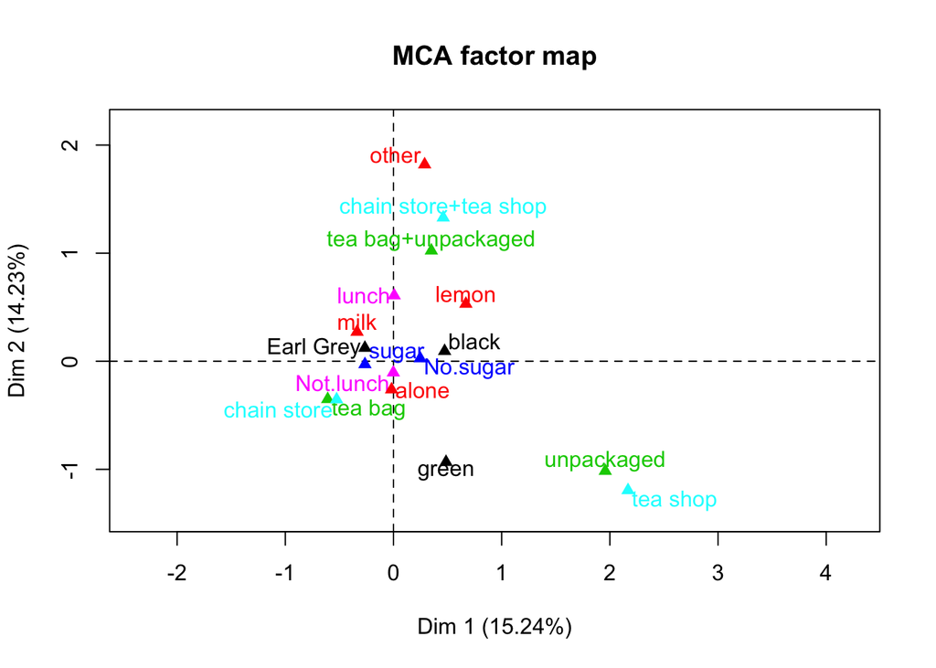